# Clase 05 - Guía técnicas avanzadas para realizar EDA.

DBT 845 - Investigación reproducible y análisis de datos biotecnológicos con R

Dr. José A. Gallardo y Dra. María Angélica Rueda.

Pontificia Universidad Católica de Valparaíso  
jose.gallardo@pucv.cl

03 April 2022

#### *Tranformación y manipulación de datos.*

La transformación y manipulación de datos es una de las actividades que más tiempo demanda durante un análisis exploratorio ya que implica tanto dar el formato adecuado para realizar los análisis estadísticos, como aplicar transformaciones sobre las variables de interés. Este proceso se lleva a cabo con el fin de generar un conjunto de datos limpio y diferente del set de datos original, adecuado para su *posterior* análisis.

La manipulación de datos se puede resumir, pero no limitar, a cinco operaciones básicas:

**1.-** **Transformar un conjunto de datos desordenado (messy) a ordenado (Tidy)**

Tres caracteristicas nos permiten reconocer si nuestros datos están ordenados o no para ser manipulados por R de forma natural y eficiente.

| **Tidy data (datos ordenados)** | **Messy data (desordenados)** |
| --- | --- |
| Cada columna es una variable | Cualquier conjunto de datos que no cumple alguno de estos criterios |
| Cada fila es una observación |  |
| Cada celda es un simple dato o valor |  |

**2.-** **Extraer subconjuntos de datos**

Ya sea por filas utilizando algún criterio o por columnas (variables) donde no es necesario considerar a todas las variables presentes en la base de datos original.

**3.-** **Transformar variables**

La transformación de datos implica realizar operaciones aritméticas o lógicas sobre las variables de interes. En general cuando una **variable es continua** realizamos operaciones *aritméticas* y cuando es **categórica** operaciones *lógicas*.

**4.-** **Resumir los datos**

Se puede resumir la información por variable calculando por ejemplo valores promedio, desviaciones estándar, valores mínimos o máximos.

**5.-** **Compactar o unir con otros conjuntos de datos**

Es posible que en tiempos posteriores surjan nuevas bases de datos que pueden enriquecer nuestros análisis, es muy útil combinar/compactar dicha información de forma homogénea en una sola base de datos.

#### *Visualización de datos.*

Como ya hemos mencionado, en la etapa de análisis exploratorio de datos es muy importante hacer representaciones gráficas o visualizar los datos, durante la etapa de manipulación esto nos permitirá:

- Detectar posibles valores atípicos u “outliers” en inglés.
- Identificar la posible distribución subyacente de la variable respuesta **(Y)**.
- Analizar posibles relaciones/asociaciones entre la variable respuesta **(Y)** y alguna variable explicativa **(X)**.
- Sintetizar de forma gráfica la información relevante de los datos.

En esta guía continuaremos trabajando con librería **ggplot2**, que como ya hemos visto contiene la función *ggplot()* con la que se generan gráficos tanto visualmente informativos como de agradable aspecto. Pero además trabajaremos con varias funciones del paquete [dplyr](https://dplyr.tidyverse.org/), y algunas del paquete [tidyr](https://tidyr.tidyverse.org/). En conjunto estos paquetes son una herramientas muy poderosas de R para transformar y manipular datos de forma efectiva.

#### **Comandos para realizar gráficas avanzadas con ggplot2**

| **Comandos** | **Función** |
| --- | --- |
| **ggplot():** | Comando base sobre el cual se realizan gráficas avanzadas. |
| **geom_point():** | Argumento que se adiciona a la función ggplot() para generar diagramas de dispersión. |
| **geom_line():** | Argumento que se adiciona a la función ggplot() para generar diagramas de líneas. |
| **geom_col():** | Argumento que se adiciona a la función ggplot() para generar diagramas de barras. |
| **geom_histogram():** | Argumento que se adiciona a la función ggplot() para generar histogramas. |
| **geom_boxplot():** | Argumento que se adiciona a la función ggplot() para generar gráficos de cajas y bigotes. |
| **facet_wrap(~ variable):** | Argumento que se adiciona a la función ggplot() para que realice tantos gráficos según los niveles que tenga la variable. |

#### **Comandos para manipular datos con dplyr**

[output not shown]

#### **Objetivos de aprendizaje**

Los objetivos de aprendizaje de esta guía son:

**1**. - Realizar un análisis exploratorio de datos.

**2**. - Realizar gráficas avanzadas con **ggplot2**.

**3**- - Realizar transformación y manipulación de datos con **tidyr** y **dplyr**.

## **Ejercicios**

### **Ejercicio 1.** Elaborar un Script de R (Archivo .R)

Elabore un archivo o file con extensión **.R** usando la barra de herramientas de **Rstudio**. Selecciona **File > New file > R script**. Utilice el siguiente ejemplo para completar la información de **metadatos** del script.

```
# ----------------------------------------------------------
# Clase 5 - Técnicas avanzadas para realizar EDA.
# Su nombre.
# Fecha de hoy.
# DBT 845 - Investigación reproducible y análisis de datos biotecnológicos con R.
# ----------------------------------------------------------
```

Luego, guarde inmediatamente su script como **script_EDA_nombre_apellido.R**.

### **Ejercicio 2.** **Configuración del Script**

Cargue los paquetes **readxl**, **stats**,**dplyr**, **tidyr**, **ggplot2** y **forcats** usando la función *library()*.

### **Ejercicio 3.** **Importar datos y transformar datos a R en formato TIDY**

En el siguiente ejercicio deberá realizar la manipulación de un pequeño conjunto de datos desordenado (messy) de respuesta a vacunación en bovinos obtenido desde el trabajo de (Parlane et al, 2014. En cual se describe en la tabla 1.

**a)** **Explorar o ordenar archivo excel.**  
Explore el archivo excel y observe que los datos no están adecuadamente ordenados para ser importados a R. Edite el archivo excel para eliminar la leyenda de la figura y para que los datos estén ubicados en la celda A1 como se muestra en la siguiente figura.

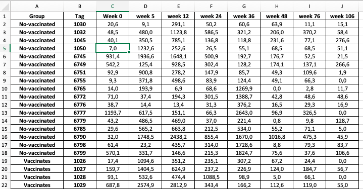

**b)** **Importar y preparar datos ordenados Tidy** Cree un objeto llamado **messy_vacunas** e importe dentro de este objeto el set de datos **vacunas.xlsx**. Use la función *read_excel()* de la librería **readxl**. Note que las variables Group y Tag están adecuadamente ordenados para analizar con R, pero no así las variables week 0 a week 106 pues todas ellas representan la respuesta de INF a la vacunación. Use la función **gather()** del paquete tidyr para ordenar las columnas 3-10 a formato tidy creando un nuevo objeto llamado “tidy_vacunas” con las nuevas variables “Week” e “IFN response”.

El objeto tidy debería visualizarse como la siguiente tabla.

```
## # A tibble: 6 × 4
##     Tag Group         Week  `IFN response`
##   <dbl> <chr>         <chr>          <dbl>
## 1  1030 No-vaccinated 0               20.6
## 2  1032 No-vaccinated 0               48.5
## 3  1045 No-vaccinated 0               40.1
## 4  1050 No-vaccinated 0                7
## 5  6745 No-vaccinated 0              931.
## 6  6749 No-vaccinated 0              542.
```

### **Ejercicio 4.** **Explorar y resumir datos**

**a)** **Explorar y transformar variables** Explore el set de datos tidy_vacunas usando las funciones **head()** y **str()** y luego transforme la variable **Group**, **Tag** a factor usando **as.factor()** y **Week** a número usando **as.numeric**. Use **summary** para visualizar que las variables fueron trasformadas adecuadamente a factor. Finalmente use la función **table()** para evaluar si los datos están o no balanceados respecto de los tratamientos **Group** y **Week**.

```
## # A tibble: 6 × 4
##     Tag Group         Week  `IFN response`
##   <dbl> <chr>         <chr>          <dbl>
## 1  1030 No-vaccinated 0               20.6
## 2  1032 No-vaccinated 0               48.5
## 3  1045 No-vaccinated 0               40.1
## 4  1050 No-vaccinated 0                7
## 5  6745 No-vaccinated 0              931.
## 6  6749 No-vaccinated 0              542.
```

```
## tibble [632 × 4] (S3: tbl_df/tbl/data.frame)
##  $ Tag         : num [1:632] 1030 1032 1045 1050 6745 ...
##  $ Group       : chr [1:632] "No-vaccinated" "No-vaccinated" "No-vaccinated" "No-vaccinated" ...
##  $ Week        : chr [1:632] "0" "0" "0" "0" ...
##  $ IFN response: num [1:632] 20.6 48.5 40.1 7 931.4 ...
```

```
##       Tag                Group          Week         IFN response
##  1026   :  8   No-vaccinated:136   Min.   :  0.00   Min.   :-578.13
##  1027   :  8   Vaccinated   :496   1st Qu.: 10.25   1st Qu.:  67.89
##  1028   :  8                       Median : 30.00   Median : 198.01
##  1029   :  8                       Mean   : 38.38   Mean   : 507.25
##  1030   :  8                       3rd Qu.: 55.00   3rd Qu.: 616.27
##  1032   :  8                       Max.   :106.00   Max.   :5246.06
##  (Other):584
```

```
##
##                  0  5 12 24 36 48 76 106
##   No-vaccinated 17 17 17 17 17 17 17  17
##   Vaccinated    62 62 62 62 62 62 62  62
```

**b)** **Filtrar datos por un criterio de clasificación**

Del conjunto de datos **tidy_vacunas** seleccione solo la información del grupo **Vaccinated**. Para ello combine una tubería **%>%** con la función *filter()*, dentro de filter use el argumento *Group == Vaccinated*.

```
## # A tibble: 496 × 4
##    Tag   Group       Week `IFN response`
##    <fct> <fct>      <dbl>          <dbl>
##  1 1026  Vaccinated     0           17.4
##  2 1027  Vaccinated     0          160.
##  3 1028  Vaccinated     0           93.1
##  4 1029  Vaccinated     0          688.
##  5 1034  Vaccinated     0          206.
##  6 1035  Vaccinated     0           58.3
##  7 1036  Vaccinated     0           25.6
##  8 1037  Vaccinated     0           63.0
##  9 1038  Vaccinated     0           33.0
## 10 1039  Vaccinated     0          118.
## # … with 486 more rows
```

**c)** **Filtrar datos por dos criterios de clasificación**

Del set de datos **tidy_vacunas** seleccione solo los datos del Grupo **Vaccinated** y de la semana **week 24** simultaneamente. Para ello combine una tubería **%>%** con la función *filter()*. Dentro de filter use el argumento *Group == “Vaccinated”* y *Week == “24”*.

```
## # A tibble: 62 × 4
##    Tag   Group       Week `IFN response`
##    <fct> <fct>      <dbl>          <dbl>
##  1 1026  Vaccinated    24           235.
##  2 1027  Vaccinated    24           237.
##  3 1028  Vaccinated    24          1088.
##  4 1029  Vaccinated    24           343.
##  5 1034  Vaccinated    24           365.
##  6 1035  Vaccinated    24           154.
##  7 1036  Vaccinated    24           117.
##  8 1037  Vaccinated    24           681.
##  9 1038  Vaccinated    24           250.
## 10 1039  Vaccinated    24           578.
## # … with 52 more rows
```

**d)** **Calcular medidas resumen**

```
## # A tibble: 1 × 1
##   `mean(\`IFN response\`)`
##                      <dbl>
## 1                     554.
```

```
## # A tibble: 1 × 6
##   `n()` `mean(\`IFN respo… `median(\`IFN re… `min(\`IFN respo… `max(\`IFN respo…
##   <int>              <dbl>             <dbl>             <dbl>             <dbl>
## 1   496               554.              223.             -578.             5246.
## # … with 1 more variable: sd(`IFN response`) <dbl>
```

Ahora, cambie los títulos de cada columna agregando al código anterior un nuevo nombre entre comillas. Siga este ejemplo para la primera columna **summarize(“N” = n()** y complete para las columnas restantes.

```
## # A tibble: 1 × 6
##       N  Mean Median Minimun Maximun `Standard deviation`
##   <int> <dbl>  <dbl>   <dbl>   <dbl>                <dbl>
## 1   496  554.   223.   -578.   5246.                 725.
```

Finalmente, para publicar una tabla resumen de forma profesional debemos crear un objeto llamado **Table**, almacenar nuestra última tabla resumen en el y luego imprimirla con el comando **knitr::kable()** de la librería **knitr**. Incluya dentro de **knitr::kable()** una leyenda de la tabla con el argumento *caption=““*. Investigue el uso de **kable** para realizar este ejercicio.

| N | Mean | Median | Minimun | Maximun | Standard deviation |
| --- | --- | --- | --- | --- | --- |
| 496 | 554.3662 | 222.5772 | -578.1275 | 5246.061 | 724.5989 |

### **Ejercicio 5.** **Graficar y exportar figuras**

**a)** **Graficar diagramas de barras con ggplot()**

Con el conjunto de datos **tidy_vacunas** elabore un gráfico de barras con la función **ggplot()** + el argumento **geom_bar()**. Use como variable de clasificación (x) **Group**.

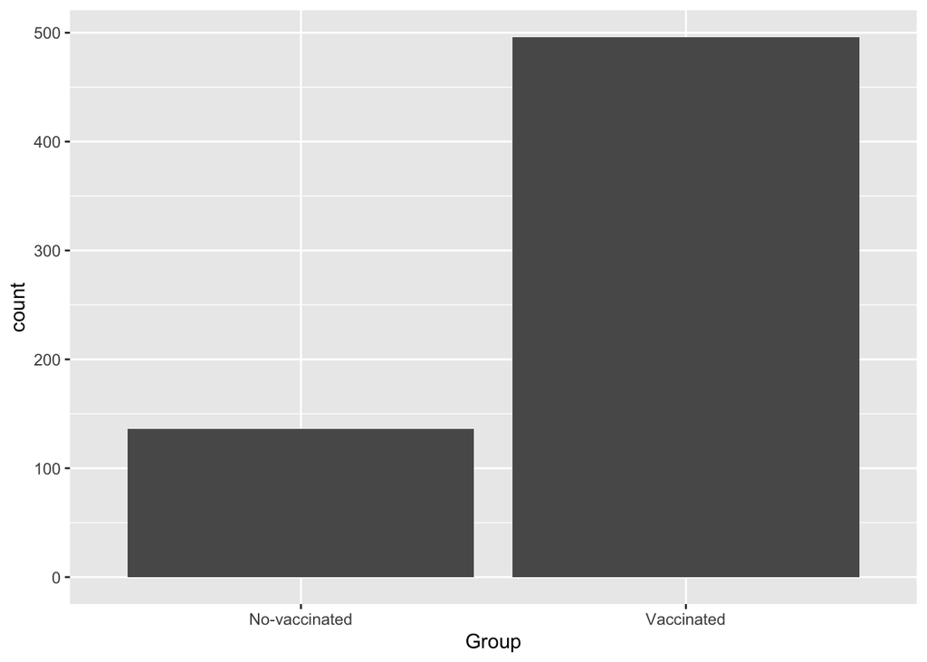

```r
ggplot(tidy_vacunas, aes(x= Group))+
   geom_bar()
```

En la gráfica anterior, coloree la variable grupo usando el argumento **fill=Group** dentro de *aes*.

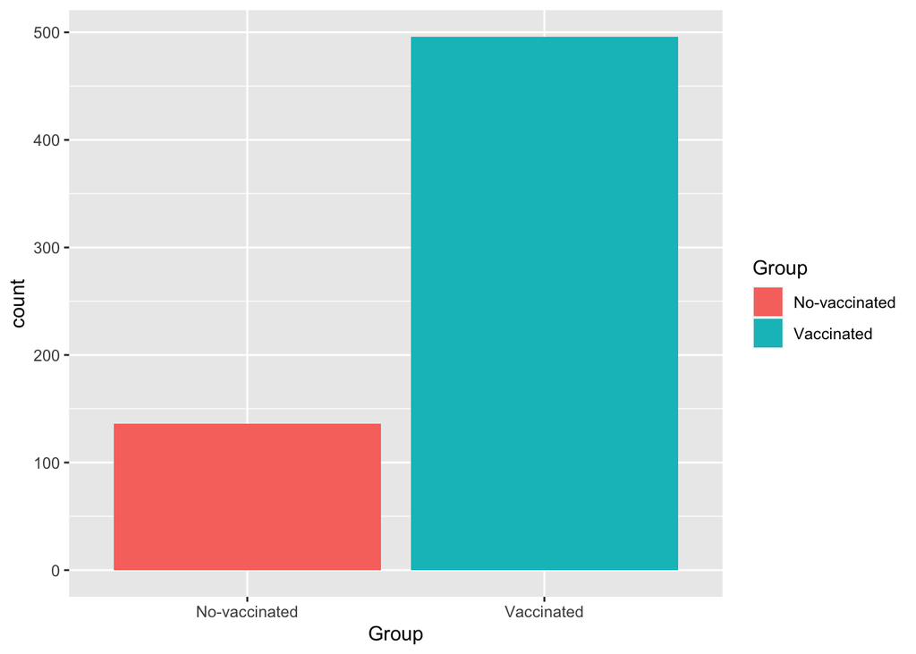

En la gráfica anterior modifique la leyenda del eje **x** con el comando **labs()**. Nombre el eje x como **““** para eliminar la leyende del eje e incluya un pie de figura”Fuente: Parlane et al, 2014” con el argumento** captions**.

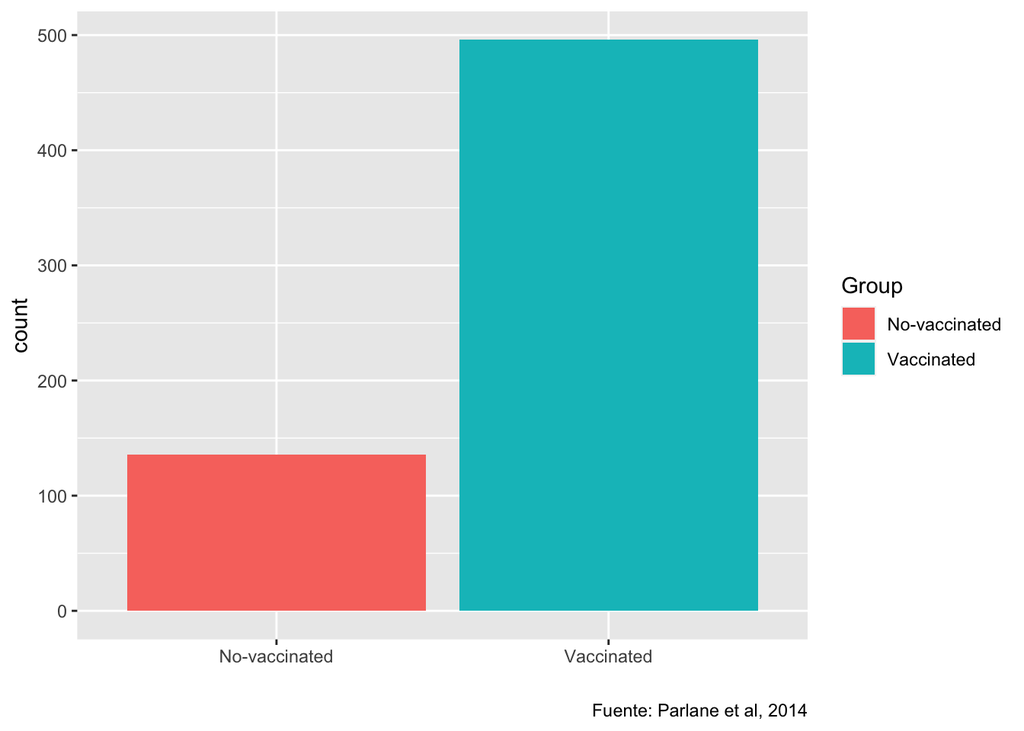

Para visualizar los datos de cada semana incluya a la gráfica anterior una nueva capa con el comando **facet_wrap(~ Week)**.

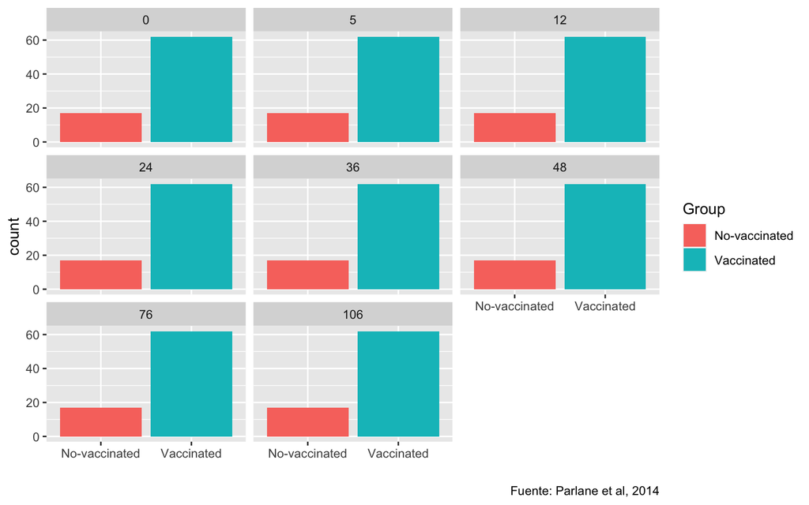

Finalmente exprtaremos la gráfica en formato de alta calidad usando los comandos **tiff()** del paquete **{grDevices}** antes del código que crea la gráfica, y el comando **dev.off()** después del comando que crea la gráfica. Use el siguiente ejemplo, pero con sus propios comandos de creación de la gráfica.

```
  tiff("IFN Gene expression.tiff", units="in", width=8, height=4, res=300, compression = 'lzw')
  ggplot())+
  geom_bar()+
  labs()+
  facet_wrap()
  dev.off()
```

### **Ejercicio 6.** **Graficar líneas con barras de error**

La función **group_by()** es muy útil para resumir información estadística agrupando por un conjunto de filas, por ejemplo, para agrupar y resumir información estadística de los diferentes niveles de un factor. Esto es usualmente usado como paso previo a realizar gráficas con medidas resumen como el promedio, la mediana y la desviación o el error estándar.

**a)** Use dos tuberías, primero para seleccionar Grupo y Semana desde el objeto **tidy_vacunas** usando la función **group_by()** y luego para calcular **n()**, el promedio **mean()** y la desviación estándar **sd()** de la variable **IFN response** usando **summarize()**.

```
## # A tibble: 16 × 5
## # Groups:   Group [2]
##    Group          Week     n   mean    sd
##    <fct>         <dbl> <int>  <dbl> <dbl>
##  1 No-vaccinated     0    17  220.  363.
##  2 No-vaccinated     5    17  554.  587.
##  3 No-vaccinated    12    17  607.  639.
##  4 No-vaccinated    24    17  232.  230.
##  5 No-vaccinated    36    17  750.  820.
##  6 No-vaccinated    48    17  137.  238.
##  7 No-vaccinated    76    17  116.  138.
##  8 No-vaccinated   106    17   66.9  85.8
##  9 Vaccinated        0    62  398.  708.
## 10 Vaccinated        5    62  999.  639.
## 11 Vaccinated       12    62 1253.  925.
## 12 Vaccinated       24    62  419.  294.
## 13 Vaccinated       36    62  982.  919.
## 14 Vaccinated       48    62  184.  226.
## 15 Vaccinated       76    62  137.  110.
## 16 Vaccinated      106    62   62.6 121.
```

**b)** Cree un objeto llamado **tidy_plot** y almacene en el las medidas resumen que calculó anteriormente. Use el siguiente comando **head(tidy_plot, 12)**.

```
## # A tibble: 12 × 5
## # Groups:   Group [2]
##    Group          Week     n   mean    sd
##    <fct>         <dbl> <int>  <dbl> <dbl>
##  1 No-vaccinated     0    17  220.  363.
##  2 No-vaccinated     5    17  554.  587.
##  3 No-vaccinated    12    17  607.  639.
##  4 No-vaccinated    24    17  232.  230.
##  5 No-vaccinated    36    17  750.  820.
##  6 No-vaccinated    48    17  137.  238.
##  7 No-vaccinated    76    17  116.  138.
##  8 No-vaccinated   106    17   66.9  85.8
##  9 Vaccinated        0    62  398.  708.
## 10 Vaccinated        5    62  999.  639.
## 11 Vaccinated       12    62 1253.  925.
## 12 Vaccinated       24    62  419.  294.
```

**c)** Ahora crearemos una variable derivada denominada **error**, en la cual calcularemos el error estándar con la fórmula **error = sd/sqrt(n)**. Para ello use el comando **mutate()**.

```
## # A tibble: 6 × 6
## # Groups:   Group [1]
##   Group          Week     n  mean    sd error
##   <fct>         <dbl> <int> <dbl> <dbl> <dbl>
## 1 No-vaccinated     0    17  220.  363.  88.1
## 2 No-vaccinated     5    17  554.  587. 142.
## 3 No-vaccinated    12    17  607.  639. 155.
## 4 No-vaccinated    24    17  232.  230.  55.9
## 5 No-vaccinated    36    17  750.  820. 199.
## 6 No-vaccinated    48    17  137.  238.  57.7
```

**c)** Finalmente crearemos una gráfica de lineas con barras de error.

Primero crearemos la primera capa con el comando **ggplot()**, incluya el argumenyo **aes** y defina como variable x= Week, como variable y=mean, y como color y group la variable Group.

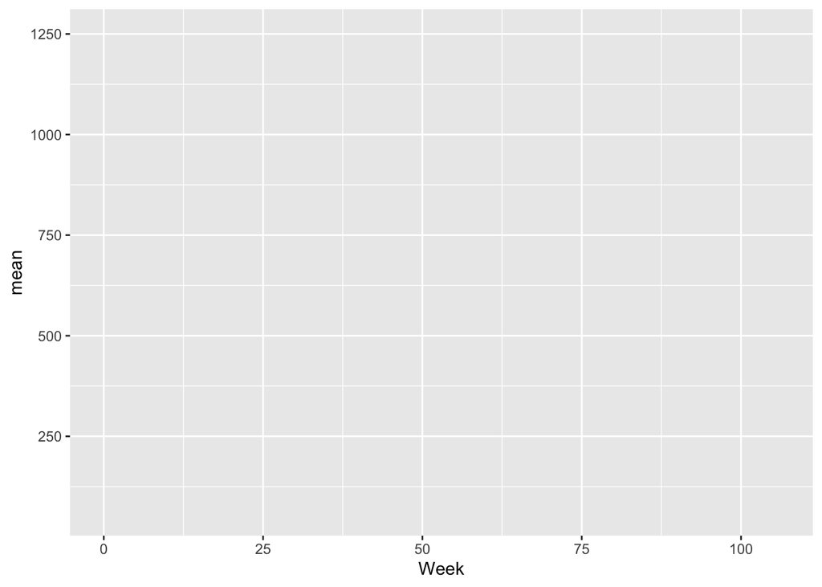

Ahora agregaremos la segunda capa con el comando **geom_line**.

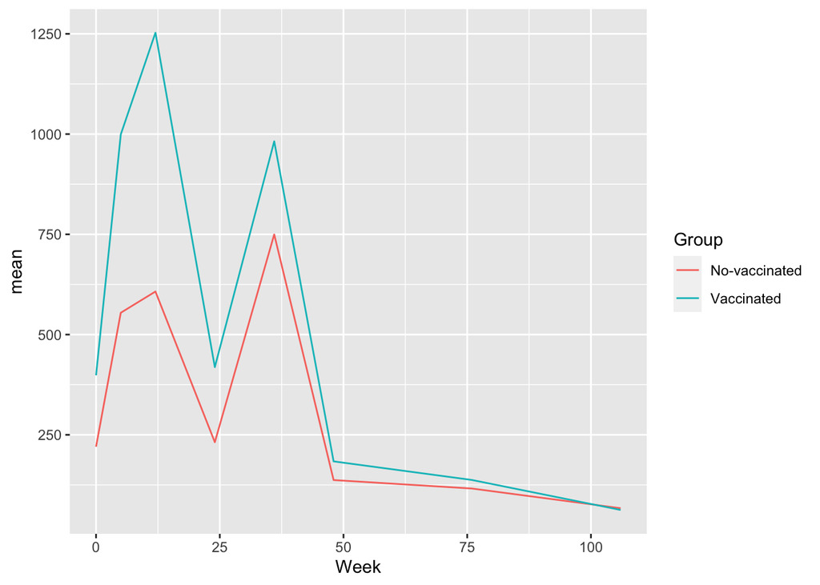

La tercera capa serán los puntos con el comando **geom_point**.

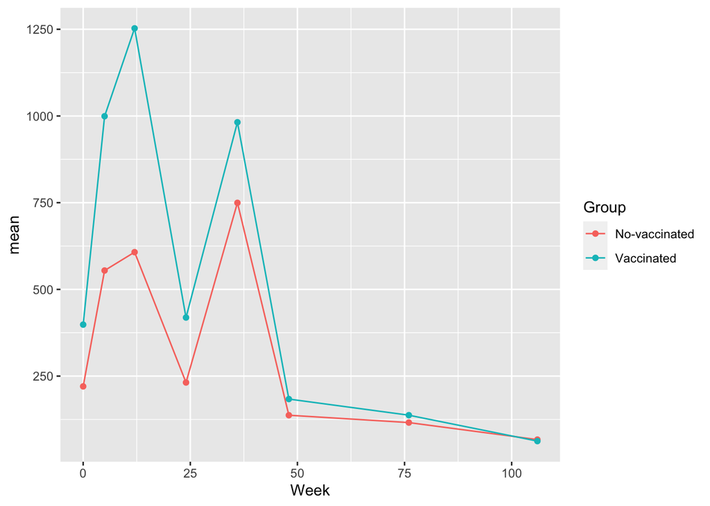

La cuarta capa serán los errores estándar con el comando **geom_errorbar**. Investigue el uso del comando **geom_errorbar()** en el siguiente [enlace](http://www.sthda.com/english/wiki/ggplot2-error-bars-quick-start-guide-r-software-and-data-visualization)

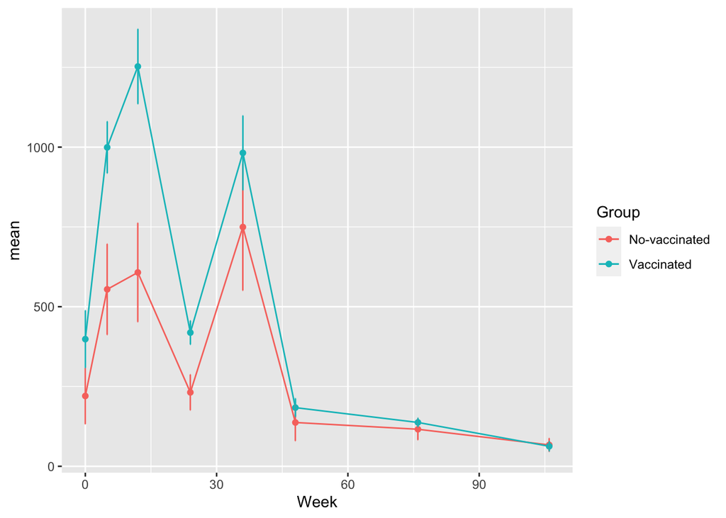

Finalmente, exportaremos la gráfica en formato **jpeg** con el comando **ggsave()** del paquete **ggplot2**. Use el siguiente ejemplo. Note que ggsave almacena siempre el ultimo gráfico creado.

```
ggsave("Plot.jpeg", width = 8, device="jpeg")
```